# Module 1 Assignment - Clustering

2023-05-01

This is a rendered R Markdown document, which means that I coded my responses directly using R instead of in a GUI interface like Rattle. Please keep this in mind when marking my assignment as my results could therefore be different to the provided answer key. I have included my code (where relevant) to help in the peer review.

## Step 1: Download and process the data

```
##                  sat top10 accept sfratio expenses grad
## Harvard         1400    91     14      11   39.525   97
## Princeton       1375    91     14       8   30.220   95
## Yale            1375    95     19      11   43.514   96
## Stanford        1360    90     20      12   36.450   93
## MIT             1380    94     30      10   34.870   91
## Duke            1315    90     30      12   31.585   95
## Cal_Tech        1415   100     25       6   63.575   81
## Dartmouth       1340    89     23      10   32.162   95
## Brown           1310    89     22      13   22.704   94
## Johns_Hopkins   1305    75     44       7   58.691   87
## U_Chicago       1290    75     50      13   38.380   87
## U_Penn          1285    80     36      11   27.553   90
## Cornell         1280    83     33      13   21.864   90
## Northwestern    1260    85     39      11   28.052   89
## Columbia        1310    76     24      12   31.510   88
## NotreDame       1255    81     42      13   15.122   94
## U_Virginia      1225    77     44      14   13.349   92
## Georgetown      1255    74     24      12   20.126   92
## Carnegie_Mellon 1260    62     59       9   25.026   72
## U_Michigan      1180    65     68      16   15.470   85
## UC_Berkeley     1240    95     40      17   15.140   78
## U_Wisconsin     1085    40     69      15   11.857   71
## Penn_State      1081    38     54      18   10.185   80
## Purdue          1005    28     90      19    9.066   69
## Texas_A&M       1075    49     67      25    8.704   67
```

## Step 2: Perform K-Means clustering

```r
kmeans_data <- data %>% select(-grad)
scaled_kmeans_data <- scale(kmeans_data)

num_clusters = 10
wss = c()

for (k in 1:num_clusters) {
  mod <- kmeans(kmeans_data, centers = k)
  wss[k] <- mod$tot.withinss
}

wss_df <- tibble(k = 1:num_clusters, tot_wss = wss)
wss_df$diff_wss <- lag(wss_df$tot_wss) - wss_df$tot_wss
wss_df <- wss_df %>% gather("variable", "value", -k)
```

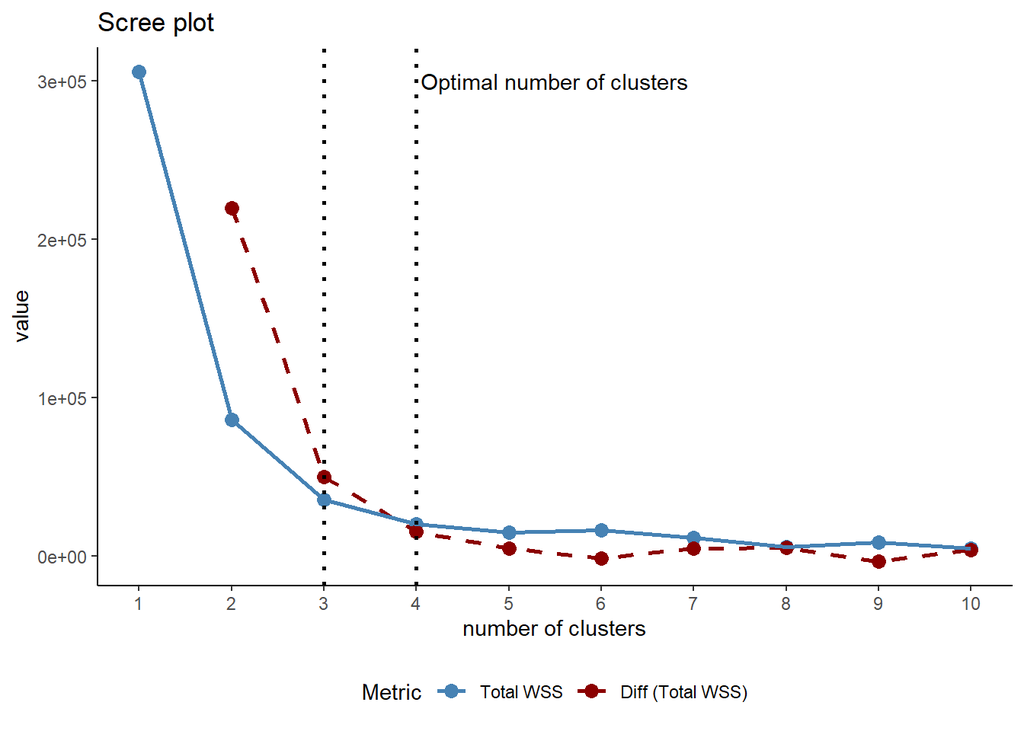

Choosing the optimal number of clusters can often involve a judggement call from the researcher. One of the most popular methods for determining the optimal number of clusters is locating the “elbow” or bend in the scree plot. In this case, it occurs at `k = 3`. An alternative method, as per the lectures, is where the total within sum of squares (Total WSS) and the difference in the Total WSS cross. Here, it’s at `k = 4`.

## Step 3: Perform K-means clustering using the optimal number of clusters

```r
set.seed(42)

best_k <- 3
mod_3 <- kmeans(scaled_kmeans_data, centers = best_k)
print(mod_3$withinss)
```

```
## [1]  8.937842 12.122192 10.478543
```

```r
best_k <- 4
mod_4 <- kmeans(scaled_kmeans_data, centers = best_k)
print(mod_4$withinss)
```

```
## [1] 8.937842 1.894033 4.573287 8.963661
```

The numbers above display the within-cluster sum of squares values for a 3-cluster and 4-cluster model respectively. Notice how I used standardised data (variables that had been scaled to each have a mean of 0 and a standard deviation of 1). This is because the results of a k-means clustering algorithm will pay more attention to variables with larger magnitudes irrespective of their actual importance.

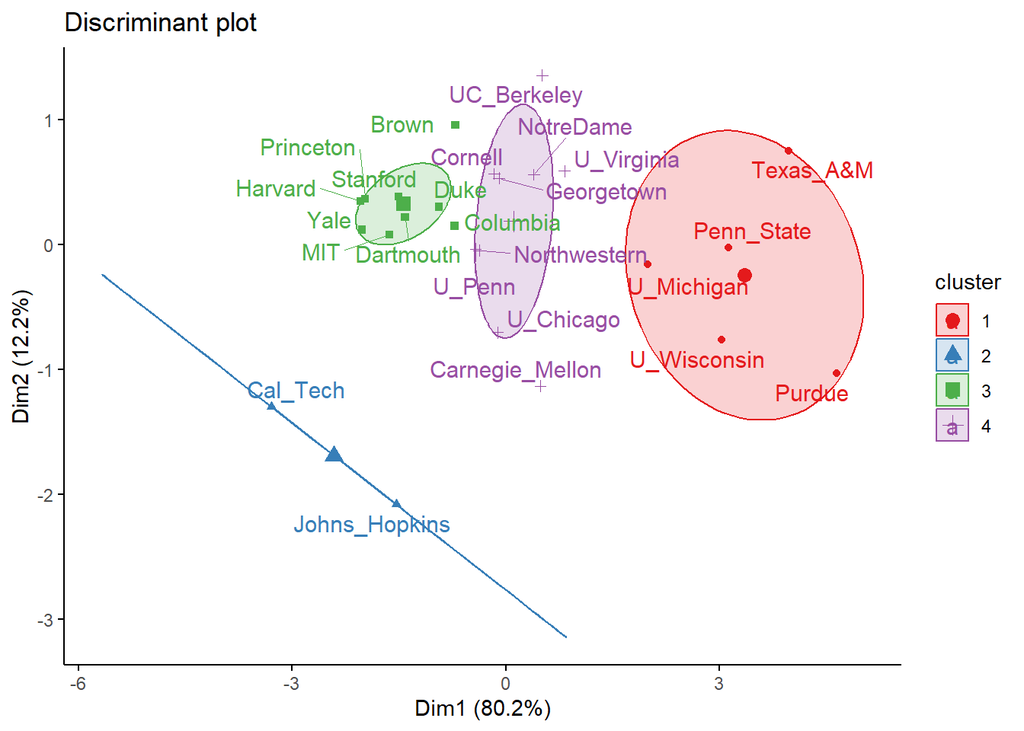

```r
fviz_cluster(mod_4, scaled_kmeans_data, repel = TRUE,
             ellipse.type = "confidence", ellipse.level = 0.999,
             palette = "Set1", main = "Discriminant plot",
             ggtheme = theme_classic())
```

After visualising the clusters (above), I determined that on the first two principal components (which explained 92.4% of the variability in the data), four clusters was possibly more appropriate. This was because Cal-Tech and John Hopkins sat slightly apart from the other three clusters.

## Step 4: Perform hierarchical clustering

In hierarchical clustering, there are several different linkage methods to choose from. However, since there is no one method that always outperforms the other, the agglomerative coefficient will be used to identify which one to use. In short, the agglomerative coefficient measures the strength of the clusters: the closer this value is to 1, the stronger the clusters.

The output below indicates that “Ward’s” method resulted in the strongest coefficient for this dataset.

```r
# define the linkage methods
m <- c("average", "single", "complete", "ward", "weighted", "gaverage")
names(m) <- c("average", "single", "complete", "ward", "weighted", "gaverage")

# calculate the agglomerative coefficient
calc_ac <- function(x) {
  agnes(scaled_kmeans_data, method = x)$ac
}

sapply(m, calc_ac)
```

```
##   average    single  complete      ward  weighted  gaverage
## 0.7642447 0.5082941 0.8659957 0.9112381 0.7895197 0.8529418
```

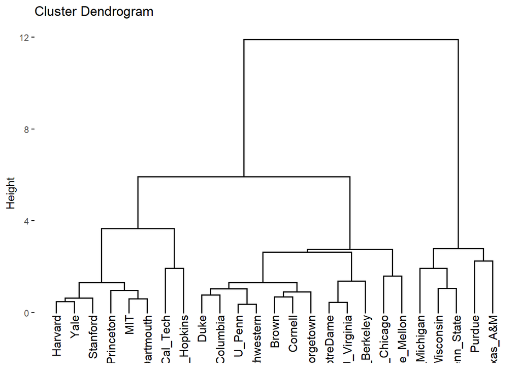

```r
clust <- agnes(scaled_kmeans_data, method ="ward")

fviz_dend(clust)
```

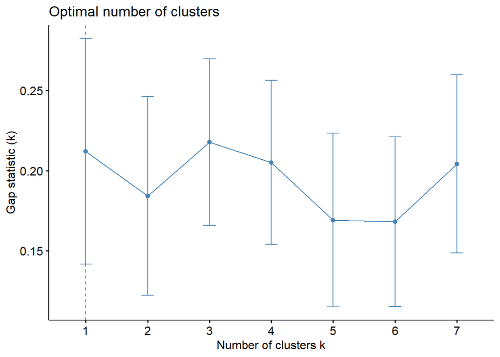

```r
gap_stat <- clusGap(scaled_kmeans_data, FUN = hcut, K.max = 7)
fviz_gap_stat(gap_stat)
```

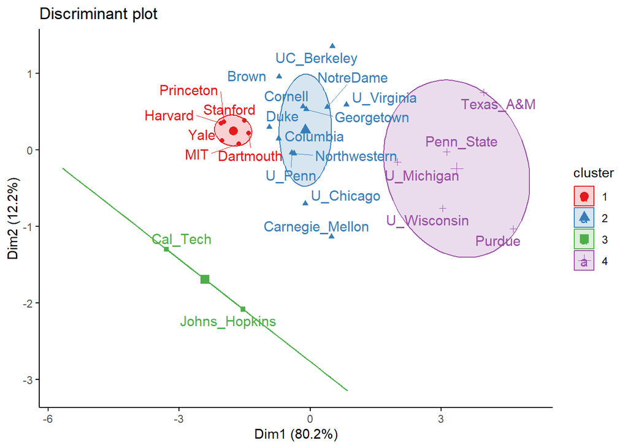

```r
clust_4 <- hcut(scaled_kmeans_data, k = 4, hc_method = "ward.D")
fviz_cluster(clust_4, repel = TRUE,
             ellipse.type = "confidence", ellipse.level = 0.999,
             palette = "Set1", main = "Discriminant plot",
             ggtheme = theme_classic())
```

Whilst the plot above looks very similar to the one produced for the k-means clustering exercise, there are three very small differences in the cluster assignments. That is, Duke, Brown and Columbia universities all switched clusters.

The very final plot below shows the original data coloured by the hierarchical clustering assignments. It indicates that whilst some sort of separation can be observed between the red universities and all the others, there is little to indicate how the others differ on just dimensions. The one exception is when `sfratio` is one of the variables, which have slightly better separation between the four clusters.

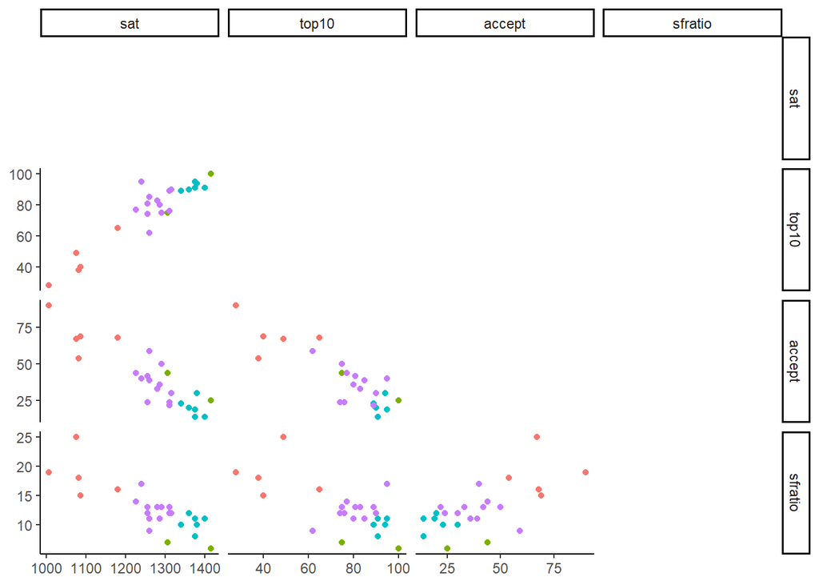

```r
GGally::ggpairs(results, mapping = aes(colour = factor(hierarchical_clusters)),
                columns = c(1:4),
                upper = "blank",
                diag = NULL) +
  theme_classic()
```